# Deep Learning — Assignment 3 — Score sheet

Third assignment for the 2024 Deep Learning course (NWI-IMC070) of the Radboud University.

Please enter your names and group number.**Names:**

**Group:**

**Instructions:**

- Fill in your names and the name of your group.
- Answer the questions and complete the code where necessary.
- Keep your answers brief, one or two sentences is usually enough.
- Re-run the whole notebook before you submit your work.
- Save the notebook as a PDF and submit that in Brightspace together with the `.ipynb` notebook file.
- The easiest way to make a PDF of your notebook is via File > Print Preview and then use your browser's print option to print to PDF.

## Objectives

This assignment is a continuation of assignment 2. We will work on the same dataset with a similar network architecture. In this assignment you will

1. Experiment with weight decay
2. Experiment with dropout
3. Experiment with early stopping

```python
%config InlineBackend.figure_formats = ['png']
%matplotlib inline
import matplotlib.pyplot as plt
import numpy as np
import torch
import time
import torchvision
import tqdm.notebook as tqdm
import collections
import IPython
import pandas as pd

plt.style.use('ggplot')

# Fix the seed, so outputs are exactly reproducible
torch.manual_seed(12345);

# Use the GPU if available
def detect_device():
    if torch.cuda.is_available():
        return torch.device("cuda")
    elif torch.backends.mps.is_available():
        return torch.device("mps")
    else:
        return torch.device("cpu")
device = detect_device()
```

## 3.1 FashionMNIST again

We will work with the same code as last week, with some slight modifications. So, we will again do experiments with the [Fashion-MNIST dataset](https://github.com/zalandoresearch/fashion-mnist).

```python
fashionmnist = torchvision.datasets.FashionMNIST(
    root=".", download=True,
    transform=torchvision.transforms.Compose([
         torchvision.transforms.ToTensor(),
         lambda img: img.flatten()
    ]))

# use 1000 samples for training, 500 for validation, ignore the rest
fashion_train, fashion_validation, _ = torch.utils.data.random_split(
    fashionmnist, [1000, 500, len(fashionmnist) - (1000 + 500)])
```

The neural network is the same as in assignment 2. We include our implementation of `build_net` here. You may substitute your own implementation instead, if you prefer.

```python
def build_net():
    return torch.nn.Sequential(
        torch.nn.Linear(784, 128),
        torch.nn.ReLU(),
        torch.nn.Linear(128, 64),
        torch.nn.ReLU(),
        torch.nn.Linear(64, 10)
    )
```

The training code is also almost the same as last time, except that we add an extra parameter to `fit`.

```python
def fit(net, train, validation, optimizer, epochs=25, batch_size=10, after_epoch=None, device=device):
    """
    Train and evaluate a network.
     - net:               the network to optimize
     - train, validation: the training and validation sets
     - optimizer:         the optimizer (such as torch.optim.SGD())
     - epochs:            the number of epochs to train
     - batch_size:        the batch size
     - after_epoch:       optional function to call after every epoch
     - device:            whether to use a gpu ('cuda') or the cpu ('cpu')

    Returns a dictionary of training and validation statistics.
    """

    # move the network parameters to the gpu, if necessary
    net = net.to(device)

    # initialize the loss and accuracy history
    history = collections.defaultdict(list)
    epoch_stats, phase = None, None

    # initialize the data loaders
    data_loader = {
        'train':      torch.utils.data.DataLoader(train, batch_size=batch_size, shuffle=True),
        'validation': torch.utils.data.DataLoader(validation, batch_size=batch_size)
    }

    # measure the length of the experiment
    start_time = time.time()

    # some advanced PyTorch to look inside the network and log the outputs
    # you don't normally need this, but we use it here for our analysis
    def register_measure_hook(idx, module):
        def hook(module, input, output):
            with torch.no_grad():
                # store the mean output values
                epoch_stats['%s %d: %s output mean' % (phase, idx, type(module).__name__)] += \
                    output.mean().detach().cpu().numpy()
                # store the mean absolute output values
                epoch_stats['%s %d: %s output abs mean' % (phase, idx, type(module).__name__)] += \
                    output.abs().mean().detach().cpu().numpy()
                # store the std of the output values
                epoch_stats['%s %d: %s output std' % (phase, idx, type(module).__name__)] += \
                    output.std().detach().cpu().numpy()
        module.register_forward_hook(hook)

    # store the output for all layers in the network
    for layer_idx, layer in enumerate(net):
        register_measure_hook(layer_idx, layer)
    # end of the advanced PyTorch code

    for epoch in tqdm.tqdm(range(epochs), desc='Epoch', leave=False):
        # initialize the loss and accuracy for this epoch
        epoch_stats = collections.defaultdict(float)
        epoch_stats['train steps'] = 0
        epoch_stats['validation steps'] = 0
        epoch_outputs = {'train': [], 'validation': []}

        # first train on training data, then evaluate on the validation data
        for phase in ('train', 'validation'):
            # switch between train and validation settings
            net.train(phase == 'train')

            epoch_steps = 0
            epoch_loss = 0
            epoch_accuracy = 0

            # loop over all minibatches
            for x, y in data_loader[phase]:
                # move data to gpu, if necessary
                x = x.to(device)
                y = y.to(device)

                # compute the forward pass through the network
                pred_y = net(x)

                # compute the current loss and accuracy
                loss = torch.nn.functional.cross_entropy(pred_y, y)
                pred_class = torch.argmax(pred_y, dim=1)
                accuracy = torch.mean((pred_class == y).float())

                # add to epoch loss and accuracy
                epoch_stats[f'{phase} loss'] += loss.detach().cpu().item()
                epoch_stats[f'{phase} accuracy'] += accuracy.detach().cpu().item()

                # store outputs for later analysis
                epoch_outputs[phase].append(pred_y.detach().cpu().numpy())

                # only update the network in the training phase
                if phase == 'train':
                    # set gradients to zero
                    optimizer.zero_grad()

                    # backpropagate the gradient through the network
                    loss.backward()

                    # track the gradient and weight of the first layer
                    # (not standard; we only need this for the assignment)
                    epoch_stats['train mean abs grad'] += \
                        torch.mean(torch.abs(net[0].weight.grad)).detach().cpu().item()
                    epoch_stats['train mean abs weight'] += \
                        torch.mean(torch.abs(net[0].weight)).detach().cpu().item()

                    # update the weights
                    optimizer.step()

                epoch_stats[f'{phase} steps'] += 1

            # compute the mean loss and accuracy over all minibatches
            for key in epoch_stats:
                if phase in key and not 'steps' in key:
                    epoch_stats[key] = epoch_stats[key] / epoch_stats[f'{phase} steps']
                    history[key].append(epoch_stats[key])

            # count the number of update steps
            history[f'{phase} steps'].append((epoch + 1) * epoch_stats[f'{phase} steps'])

            # store the outputs
            history[f'{phase} outputs'].append(np.concatenate(epoch_outputs[phase]).flatten())

        history['epochs'].append(epoch)
        history['time'].append(time.time() - start_time)

        # call the after_epoch function
        if after_epoch is not None:
            stop = after_epoch(net, epoch, epoch_stats)
            if stop is Stop:
                break

    return history

# marker to indicate stopping
Stop = "stop"
```

```python
# helper code to plot our results
class HistoryPlotter:
    def __init__(self, plots, table, rows, cols, param_names=[]):
        self.plots = plots
        self.table = table
        self.rows = rows
        self.cols = cols
        self.histories = {}
        self.results = []
        self.params = []
        self.param_names = []

        self.fig, self.axs = plt.subplots(ncols=cols * len(plots), nrows=rows,
                                          sharex='col', sharey='none',
                                          figsize=(3.5 * cols * len(plots), 3 * rows))
        plt.tight_layout()
        IPython.display.display(self.fig)
        IPython.display.clear_output(wait=True)

    # add the results of an experiment to the plot
    def add(self, title, history, row, col, epoch=-1, param=None):
        self.histories[title] = history
        self.results.append((title, {key: history[key][epoch] for key in self.table}))
        self.params.append(param)

        for plot_idx, plot_xy in enumerate(self.plots):
            ax = self.axs[row, col * len(self.plots) + plot_idx]
            for key in plot_xy['y']:
                lines = ax.plot(history[plot_xy['x']], history[key], label=key)
                if epoch >= 0:
                    ax.plot([history[plot_xy['x']][epoch]], [history[key][epoch]], marker='*', color='black')
            if 'accuracy' in plot_xy['y'][0]:
                ax.set_ylim([0, 1.01])
            ax.legend()
            ax.set_xlabel(plot_xy['x'])
            ax.set_title(title)
        plt.tight_layout()
        IPython.display.clear_output(wait=True)
        IPython.display.display(self.fig)

    # print a table of the results for all experiments
    def print_table(self):
        df = pd.DataFrame([
            { 'experiment': title, **{key: row[key] for key in self.table} }
            for title, row in self.results
        ])
        IPython.display.display(df)

    def done(self):
        plt.close()
        self.print_table()
```

## 3.2 Weight decay (6 points)

The training can be regularized using weight decay. This option is built-in in many of the PyTorch optimizers [(documentation)](https://pytorch.org/docs/stable/generated/torch.optim.Adam.html#torch.optim.Adam).

We will set up an experiment to investigate how this affects the training of the model.

We use the good settings from last week:

- Optimizer: Adam
- Learning rate: 0.0001
- Minibatch size: 32
- 150 epochs

and apply L2 weight decay with a factor 0, 0.0001, 0.001, 0.01, or 0.1.

**3.2 a Add comment(a) Complete the code below and run the experiment. (1 point)**

*Grading:*

- 1 point for a correct implementation, by adding a `weight_decay` parameter to the optimizer.

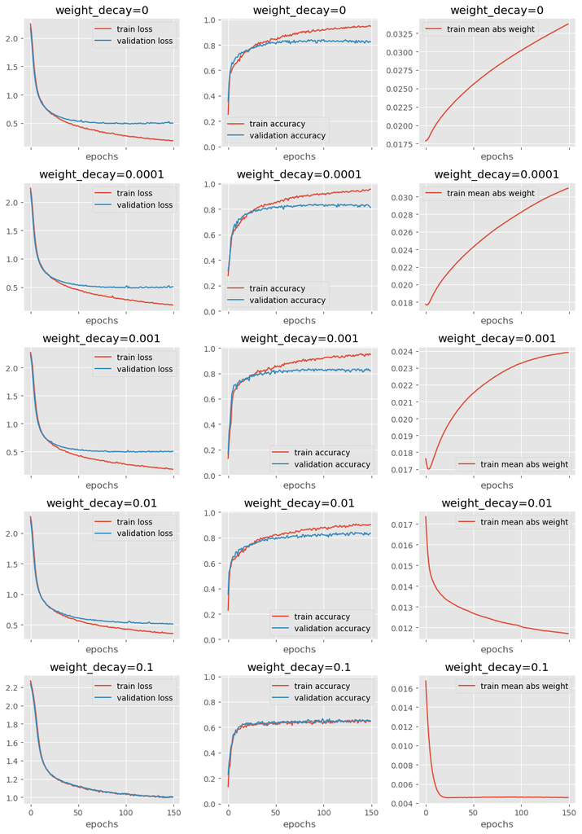

|  | experiment | train accuracy | validation accuracy | train mean abs weight |
| --- | --- | --- | --- | --- |
| 0 | weight_decay=0 | 0.946289 | 0.823828 | 0.033750 |
| 1 | weight_decay=0.0001 | 0.956055 | 0.813672 | 0.030958 |
| 2 | weight_decay=0.001 | 0.948242 | 0.820703 | 0.023916 |
| 3 | weight_decay=0.01 | 0.901367 | 0.833594 | 0.011705 |
| 4 | weight_decay=0.1 | 0.647461 | 0.650000 | 0.004592 |

```python
plotter_weight_decay = \
    HistoryPlotter(plots=[{'x': 'epochs', 'y': ['train loss', 'validation loss']},
                          {'x': 'epochs', 'y': ['train accuracy', 'validation accuracy']},
                          {'x': 'epochs', 'y': ['train mean abs weight']},],
                   table=['train accuracy', 'validation accuracy', 'train mean abs weight'],
                   param_names=['weight_decay'],
                   rows=5, cols=1)

epochs = 150
lr = 0.0001
batch_size = 32
weight_decays = [0, 0.0001, 0.001, 0.01, 0.1]

for row, weight_decay in enumerate(weight_decays):
    net = build_net()
    ### BEGIN ANSWER
    optimizer = torch.optim.Adam(net.parameters(), lr=lr, weight_decay=weight_decay)
    ### END ANSWER
    history_weight_decay = fit(net, fashion_train, fashion_validation, optimizer=optimizer, epochs=epochs, batch_size=batch_size)
    plotter_weight_decay.add(f'weight_decay={weight_decay}', history_weight_decay, row=row, col=0, param=weight_decay)

plotter_weight_decay.done()
```

**3.2 b Add comment(b) How can you observe the amount of overfitting in the plots? (1 point)**

Answer:

Overfitting is evident when there is a difference between training and validation loss. The two lines (train and validation) get closer together when there is less overfitting.

Note: there can still be overfitting even when the validation loss has converged. It just means that the model fits the training data too closely, at the expense of generalisation performance.

*Grading:*

- 1 point for a correct answer.
- 0 points for saying that the validation loss has to increase.

**3.2 c Add comment(c) How does weight decay affect the performance of the model in the above experiments? Give an explanation in terms of the amount of overfitting. (1 point)**

Answer:

More weight decay reduces overfitting, that is, it decreases the difference between train and validation accuracy. But for high amounts of weight decay, this comes at the cost of decreasing both training and validation accuracy. In that case the model is underfitting.

*Grading:*

- 1 point for a correct argument.
- 0.5 points for only saying that weight decay reduces overfitting.

In these experiments you have implemented weight decay using the built in weight decay feature of the optimizer.

An alternative is to add an L2 penaltiy to the loss: \begin{align*} L_\text{regularized}(\theta) = L(\theta) + \lambda \frac{1}{2} |\theta|_2^2, \end{align*} which results in a gradient \begin{align*} \nabla_\theta L_\text{regularized}(\theta) = \nabla_\theta L(\theta) + \lambda \theta. \end{align*} Using gradient descend will then decrease the weights.

**3.2 d Add comment(d) Are the two ways of implementing weight decay equivalent when using the Adam optimizer? (1 point)**

Hint: look at [the torch documentation for Adam](https://pytorch.org/docs/stable/generated/torch.optim.Adam.html).

Answer:

Yes, the pseudo code shows that $\lambda \theta$ is added to the gradient, so the two are equivalent.

*Grading:*

- 1 point for a correct answer.

Another way to implement weight decay, and where the name comes from, is to scale or decay the weights directly: \begin{align*} \theta \gets (1 - \lambda) \theta \end{align*}

Combined with Adam, this gives the [`AdamW` optimizer](https://pytorch.org/docs/stable/generated/torch.optim.AdamW.html).

**3.2 e Add comment(e) Are Adam and AdamW equivalent? Explain your answer. (1 point)**

Answer:

No. They are very similar, but Adam applies momentum and gradient scaling to the weight decay term as well, whereas AdamW does not.

*Grading:*

- 1 point for a correct answer.

### Learning curves

So far the only learning curves we have looked at have the number of epochs on the horizontal axis. We can also make learning curves putting another parameter on that axis.

**(f) Run the code below to plot a learning curve (no points)**

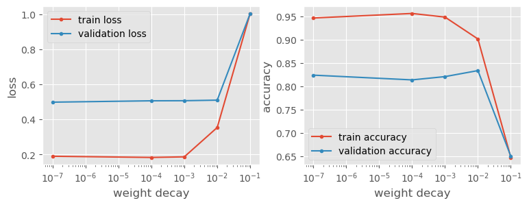

```python
weight_decays = torch.tensor(plotter_weight_decay.params) + 1e-7
  # Note: add 1e-7 to prevent log(0)

fig, axs = plt.subplots(ncols=2, nrows=1, figsize=(4.5 * 2, 3))
for i, stat in enumerate(['loss', 'accuracy']):
    keys = [f'train {stat}', f'validation {stat}']
    values = {key: [r[1][key][-1] for r in plotter_weight_decay.histories.items()] for key in keys}

    ax = axs[i]
    for key in keys:
        ax.plot(weight_decays, values[key], '.-', label=key)
    ax.set_xscale('log');
    ax.set_xlabel('weight decay');
    ax.set_ylabel(stat);
    ax.legend();
```

**3.2 g Add comment(g) Looking a this learning curve, how do you see signs of overfitting or underfitting? (1 point)**

Answer:

*Grading:*

- 1 point for a correct answer.

## 3.3 Dropout (9 points)

Next, we will do experiments with dropout. This gives another way of regularizing the training.

**3.3 a Add comment(a) Make a copy of the network architecture below, and add dropout. (1 point)**

Add dropout layers after each linear layer, except for the last.

Hint: see [torch.nn.Dropout](https://pytorch.org/docs/stable/generated/torch.nn.Dropout.html).

*Grading:*

- 1 point for a correct and working implementation.
- It doesn't matter if dropout is put before or after ReLU layers
- 0 points if you use dropout after the final layer.

```python
def build_net_with_dropout(p):
    ### BEGIN ANSWER
    return torch.nn.Sequential(
        torch.nn.Linear(784, 128),
        torch.nn.Dropout(p),
        torch.nn.ReLU(),
        torch.nn.Linear(128, 64),
        torch.nn.Dropout(p),
        torch.nn.ReLU(),
        torch.nn.Linear(64, 10)
    )
    ### END ANSWER
```

**3.3 b Add comment(b) Should you put dropout layers before or after ReLU activation functions? Does it matter? (1 point)**

*Answer:*

Conceptually, when you apply dropout directly after the linear layer you are dropping the outputs of that layer. When you apply dropout after the activation function, dropout is done before the next linear layer, so you are dropping inputs of the next layer. The latter is how dropout is usually described.

In this case it does not matter, because `dropout(relu(x)) = relu(dropout(x))`, both are equal to `max(0,x)` with probability (1-p) and to 0 with probability p.

*Grading:*

- 1 point for correctly saying it does not matter. The conceptual explanation is not needed.
- 0 points for saying that only one option is correct.

**3.3 c Add comment(c) What would happen if you put a dropout layer after the last linear layer? (1 point)**

*Answer:*

Then with probability $p$ the prediction for the true class would be 0. There would also be no gradient propagated through the dropout layer in that case, so that training sample is wasted. This would slow down training for no bennefit.

*Grading:*

- 1 point for a correct answer.

**3.3 d Add comment(d) Set up an experiment to see how dropout affects our results. (1 point)**

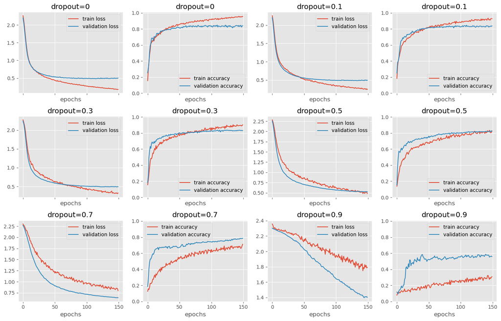

|  | experiment | train accuracy | validation accuracy | train mean abs weight |
| --- | --- | --- | --- | --- |
| 0 | dropout=0 | 0.955078 | 0.839453 | 0.034074 |
| 1 | dropout=0.1 | 0.927734 | 0.837500 | 0.032026 |
| 2 | dropout=0.3 | 0.902344 | 0.831641 | 0.029394 |
| 3 | dropout=0.5 | 0.827148 | 0.823828 | 0.026937 |
| 4 | dropout=0.7 | 0.711914 | 0.785547 | 0.023851 |
| 5 | dropout=0.9 | 0.307617 | 0.557813 | 0.018917 |

```python
plotter_dropout = \
    HistoryPlotter(plots=[{'x': 'epochs', 'y': ['train loss', 'validation loss']},
                          {'x': 'epochs', 'y': ['train accuracy', 'validation accuracy']},],
                   table=['train accuracy', 'validation accuracy', 'train mean abs weight'],
                   param_names=['dropout'],
                   rows=3, cols=2)

epochs = 150
lr = 0.0001
batch_size = 32
dropouts = [0, 0.1, 0.3, 0.5, 0.7, 0.9]

for row, dropout in enumerate(dropouts):
    ### BEGIN ANSWER
    net = build_net_with_dropout(dropout)
    optimizer = torch.optim.Adam(net.parameters(), lr=lr)
    ### END ANSWER
    history_dropout = fit(net, fashion_train, fashion_validation, optimizer=optimizer, epochs=epochs, batch_size=batch_size)
    plotter_dropout.add(f'dropout={dropout}', history_dropout, row=row//2, col=row%2, param=dropout)

plotter_dropout.done()
```

**3.3 e Add comment(e) How does dropout affect the results? (1 point)**

*Answer:*

*Grading:*

- 1 point for a correct answer.

**3.3 f Add comment(f) How does dropout affect training speed? Has the training converged in all runs? (1 point)**

*Answer:*

With dropout training slower, so we need to train longer. With large dropout valuse the training has not convered after 150 epochs.

*Grading:*

- 1 point for a correct answer.

**3.3 g Add comment(g) With a large amount of dropout, the training loss can be worse than the validation loss. How is this possible? (1 point)**

Answer:

The train loss is computed with dropout, the validation loss without dropout. With a large dropout rate this adds a lot of noise, leading to worse results.

*Grading:*

- 1 point for correctly saying that train loss uses dropout and validation loss does not.

**3.3 h Add comment(h) Plot a learning curve for the dropout parameter (1 point)**

You should use a linear scale for the x-axis. Be sure to use the right histories, and to label your axes.

*Grading:*

- 1 point for a good plot.
- -0.5 points for not labeling the axes correctly.
- 0 points if not using stats from `plotter_dropout`.

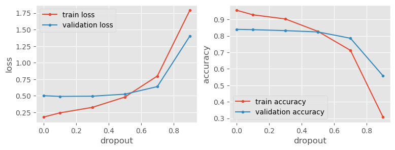

```python
### BEGIN ANSWER
params = torch.tensor(plotter_dropout.params)

fig, axs = plt.subplots(ncols=2, nrows=1, figsize=(4.5 * 2, 3))
for i, stat in enumerate(['loss', 'accuracy']):
    keys = [f'train {stat}', f'validation {stat}']
    values = {key: [r[1][key][-1] for r in plotter_dropout.histories.items()] for key in keys}

    ax = axs[i]
    for key in keys:
        ax.plot(params, values[key], '.-', label=key)
    ax.set_xlabel('dropout');
    ax.set_ylabel(stat);
    ax.legend();
### END ANSWER
```

**3.3 i Add comment(i) Does the above learning curve show a clear optimum? (1 point)**

Answer:

*Grading:*

- 1 point for a correct answer.

## 3.4 Early stopping (7 points)

If you look at the learning curves of the unregularised models, you can see that the validation loss starts to go up after a certain amount of training. It would be good to stop at that point, which is called early stopping.

There are two ways to implement early stopping:

1. Run the training for a fixed number of epochs, but keep track of the best result on the validation set.
2. Run until the validation loss does not decrease for a certain number of epochs.

Only the second option is actually early *stopping*, but the first option can be easier to implement.

**3.4 a Add comment(a) Implement the first style of early stopping, and run the experiment below. (2 points)**

You can pass a function to the `after_epoch` parameter of `fit`. This function is called after every epoch.

The `epoch` parameter to `plotter.add` highlights a specific epoch in the results with a star, and selects it for the table.

*Grading:*

- 1 point for implementing 'best' as lowest validation loss.
- 1 point for updating the best epoch and loss inside an if statement.

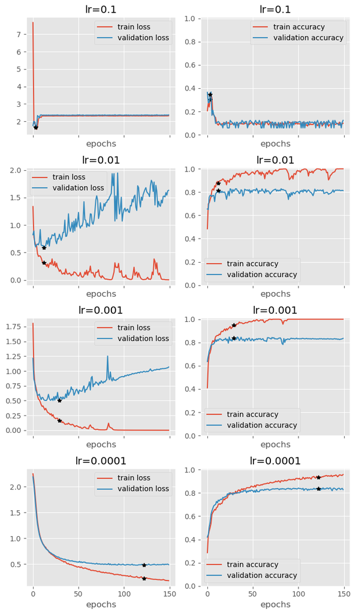

|  | experiment | train loss | validation loss | train accuracy | validation accuracy | epochs |
| --- | --- | --- | --- | --- | --- | --- |
| 0 | lr=0.1 | 1.693911 | 1.655180 | 0.301758 | 0.346094 | 3 |
| 1 | lr=0.01 | 0.314144 | 0.588655 | 0.875977 | 0.815625 | 12 |
| 2 | lr=0.001 | 0.162162 | 0.500397 | 0.948242 | 0.837109 | 29 |
| 3 | lr=0.0001 | 0.225281 | 0.478702 | 0.934570 | 0.835547 | 122 |

```python
plotter_early_stop = \
    HistoryPlotter(plots=[{'x': 'epochs', 'y': ['train loss', 'validation loss']},
                          {'x': 'epochs', 'y': ['train accuracy', 'validation accuracy']}],
                   table=['train loss', 'validation loss', 'train accuracy', 'validation accuracy', 'epochs'],
                   rows=4, cols=1)

epochs = 150
lr = 0.001
lrs = [0.1, 0.01, 0.001, 0.0001]
batch_size = 32

for row, lr in enumerate(lrs):
    # the best network, epoch at which we found it, and stats
    best_net = None
    best_epoch = 0
    best_stats = {'train loss': torch.inf, 'validation loss': torch.inf, 'train accuracy': 0, 'validation accuracy': 0}

    def track_best(net, epoch, epoch_stats):
        global best_net, best_epoch, best_stats
        ### BEGIN ANSWER
        if epoch_stats['validation loss'] < best_stats['validation loss']:
            best_net = net
            best_epoch = epoch
            best_stats = epoch_stats
        ### END ANSWER

    net = build_net()
    optimizer = torch.optim.Adam(net.parameters(), lr=lr)
    history_early_stop = fit(net, fashion_train, fashion_validation, optimizer=optimizer, epochs=epochs, batch_size=batch_size, after_epoch=track_best)
    plotter_early_stop.add(f'lr={lr}', history_early_stop, row=row, col=0, epoch=best_epoch)

plotter_early_stop.done()
```

**3.4 b Add comment(b) Looking at the results, does early stopping prevent overfitting? (1 point)**

*Answer:*

Yes, it stops overfitting that results from training too long. For example with lr=0.01 the validation loss goes up with more training, but we pick the best result before that point.

*Grading:*

- 1 point for a correct answer.

**3.4 c Add comment(c) Is it fair to compare the validation loss you get with early stopping to the loss without early stopping? Briefly explain your answer. (1 point)**

*Answer:*

No, with early stopping you pick the best validation loss. So it will always be lower than the loss without early stopping. That does not mean that the model is actually better. To determine that you would need to use an independent test set.

*Grading:*

- 1 point for a correct answer.
- 0.5 points for only "no".

Copying a neural network with `net2 = net1` makes a shallow copy, that is, the two variables refer to the same network in memory.

**3.4 d Add comment(d) If you used `best_net = net` in `track_best`, would `best_net` contain the optimal early stopping parameters after training? If not, how could you get access to them? (1 point)**

*Answer:*

No, the parameters are shared, and they are updated with more training.

You could save the best parameters to a file with `torch.save`, or make a deep copy with `deepcopy`.

*Grading:*

- 0.5 points for 'no'
- 0.5 points for a solution.

### Actual early *stopping*

It is wasteful to keep training if we know that the loss is only getting worse. So we might as well stop at that point.

**3.4 e Add comment(e) Implement the second variant of early stopping: stop training if the validation loss does not decrease for 5 epochs. (1 point)**

Hint: The `fit` function will stop the training if the `after_epoch` function returns `Stop`.

*Grading:*

- 1 point for a correct implementation of early stopping.

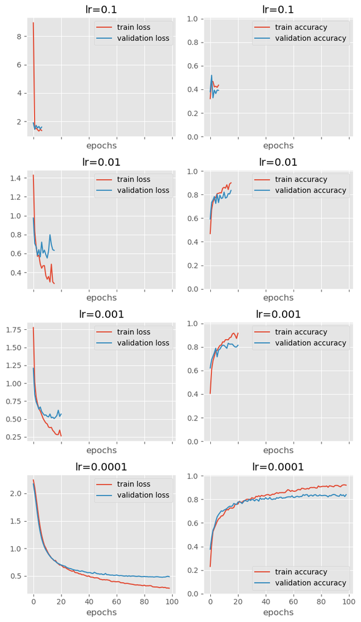

|  | experiment | train loss | validation loss | train accuracy | validation accuracy | epochs |
| --- | --- | --- | --- | --- | --- | --- |
| 0 | lr=0.1 | 1.348713 | 1.592508 | 0.435547 | 0.391797 | 6 |
| 1 | lr=0.01 | 0.282413 | 0.632223 | 0.899414 | 0.835156 | 15 |
| 2 | lr=0.001 | 0.265443 | 0.568926 | 0.916016 | 0.814062 | 20 |
| 3 | lr=0.0001 | 0.275384 | 0.484959 | 0.919922 | 0.839453 | 98 |

```python
plotter_early_stop2 = \
    HistoryPlotter(plots=[{'x': 'epochs', 'y': ['train loss', 'validation loss']},
                          {'x': 'epochs', 'y': ['train accuracy', 'validation accuracy']}],
                   table=['train loss', 'validation loss', 'train accuracy', 'validation accuracy', 'epochs'],
                   rows=4, cols=1)

epochs = 150
lr = 0.001
lrs = [0.1, 0.01, 0.001, 0.0001]
batch_size = 32

for row, lr in enumerate(lrs):
    best_net = None
    best_epoch = 0
    best_stats = {'train loss': torch.inf, 'validation loss': torch.inf, 'train accuracy': 0, 'validation accuracy': 0}

    def stop_if_no_loss_decrease(net, epoch, epoch_stats):
        global best_net, best_epoch, best_stats
        ### BEGIN ANSWER
        if epoch_stats['validation loss'] < best_stats['validation loss']:
            best_net = net
            best_epoch = epoch
            best_stats = epoch_stats
        if epoch >= best_epoch + 5:
            return Stop
        ### END ANSWER

    net = build_net()
    optimizer = torch.optim.Adam(net.parameters(), lr=lr)
    history_early_stop2 = fit(net, fashion_train, fashion_validation, optimizer=optimizer, epochs=epochs, batch_size=batch_size, after_epoch=stop_if_no_loss_decrease)
    plotter_early_stop2.add(f'lr={lr}', history_early_stop2, row=row, col=0)

plotter_early_stop2.done()
```

**3.4 f Add comment(f) With the second variant of early stopping, is the network after training the optimal one? (1 point)**

*Answer:*

No, we only stop if the validation loss did not decrease for 5 epochs, so the network has gotten a bit worse during that time.

*Grading:*

- 1 point for a correct answer.

## 3.5 Hyperparameter optimization (3 points)

We have seen quite a few hyperparameters this week and last week. To pick the optimal parameters, one strategy would be to do what we have done, and run an experiment for each parameter individually.

**3.5 a Add comment(a) Look at the previous experiments, and pick the best hyperparameter values. (1 point)**

Optionally: look at the experiments from assignment 2 and also pick the optimal network width.

*Answer:*

*Grading:*

- The optimal values should be reported here. They may be slightly different, depending on the random variations in the experiments.

**3.5 b Add comment(b) If you select the hyperparameters this way, will you get the best results? Explain your answer. (1 point)**

*Answer:*

No, it is possible that the optimal value for one hyperparameter depends on another. For example the optimal learning rate for Adam is different from the optimal one for SGD.

*Grading:*

- 1 point for the correct answer.
- 0.5 points for only "no" without an explanation.

An alternative is to use a grid search, and try all possible combinations of hyperparameters.

**3.5 c Add comment(c) How many experiments would you need to do to explore all combinations of learning rate, weight decay, and dropout that we used in this assignment? (1 point)**

*Answer:*

We used 4 learning rates, 5 weight decays, and 6 dropout values. So `4*5*6=120` experiments.

*Grading:*

- 1 point for the right answer.

## The end

Well done! Please double check the instructions at the top before you submit your results.

*This assignment has 25 points.* Version 3e03fe7 / 2024-09-24

## Score form

Download the scores as a text file